# Planula GO Term Enrichment Analysis

Erin Chille

2021/04/23

Load necessary libraries

```r
rm(list = ls()) #clear environment
library(goseq)
library(tidyverse)
library(GSEABase)
library(data.table)
```

```r
library(ggplot2)
library(cowplot)
library(patchwork)
```

Import the data files

```r
#treatment information
treatmentinfo <- read.csv("Sample_Info/RNAseq_data.csv", header = TRUE, sep = ",")
str(treatmentinfo)
```

```
## 'data.frame':    44 obs. of  4 variables:
##  $ sample_id       : chr  "X119" "X120" "X121" "X127" ...
##  $ time_point      : chr  "Unfertilized_egg" "Unfertilized_egg" "Unfertilized_egg" "Fertilized_egg" ...
##  $ treatment       : chr  "amb" "amb" "amb" "amb" ...
##  $ extraction_batch: int  0 0 12 10 11 10 8 11 10 9 ...
```

```r
head(treatmentinfo)
```

```
##   sample_id       time_point treatment extraction_batch
## 1      X119 Unfertilized_egg       amb                0
## 2      X120 Unfertilized_egg       amb                0
## 3      X121 Unfertilized_egg       amb               12
## 4      X127   Fertilized_egg       amb               10
## 5      X128   Fertilized_egg         l               11
## 6      X129   Fertilized_egg        xl               10
```

```r
#gene count matrix
gcount <- as.data.frame(read.csv("2-QC-Align-Assemble/Output/gene_count_matrix.csv", row.names="gene_id"))
gcount <- gcount[ ,treatmentinfo$sample_id] #remove samples not in the treatment information csv (i.e. not in experiment)
gcount$gene_id <- rownames(gcount)
rownames(gcount) <- NULL
dim(gcount)
```

```
## [1] 63227    45
```

```r
#DESeq2 and clustering results
DEG.res <- read.csv("4-Differential-Gene-Expression-Analysis/Output/pln_DEGs_all.csv")[,-1]
nrow(DEG.res)
```

```
## [1] 8360
```

```r
#filter DEGs for log2FoldChange>|1|
DEG.res <- filter(DEG.res, log2FoldChange > 1 | log2FoldChange < (-1))
nrow(DEG.res)
```

```
## [1] 1257
```

```r
#transcript annotations
annot <- read_tsv( "1-BLAST-GO-KO/Output/200824_Mcap_Blast_GO_KO.tsv", col_names = TRUE) #biological annotation information
Go.ref <- subset(annot, select= c(gene_id, length)) #Select only relevant information

#Filter gcount by available annotations
Go.ref <- merge(gcount, Go.ref, by = "gene_id")
```

Make a dataframe containing the gene_ids and cluster for each cluster.

```r
#Select only gene_id and cluster from DEseq2 res
DEGclust <- subset(DEG.res, select=c(gene_id, cluster))
DEGclust <- unique(DEGclust)

clust1 <- filter(DEGclust, cluster=="1")
nrow(clust1) #nrow clust1
```

```
## [1] 344
```

```r
clust2 <- filter(DEGclust, cluster=="2")
nrow(clust2) #nrow clust2
```

```
## [1] 256
```

Set ID and gene length vectors, and make a binary matrix indicating which genes are differentially expressed. These are used as input to nullp, which for calculates a Probability Weighting Function for each set of DEGs.

```r
#Make ID and length vectors
Go.ref <- unique(Go.ref)
dim(Go.ref)
```

```
## [1] 55217    46
```

```r
IDvector <- Go.ref$gene_id
lengthVector <- Go.ref$length

#Cluster 1
clust1.genes <- as.vector(clust1$gene_id)
clust1.genes=as.integer(Go.ref$gene_id%in%clust1.genes)
names(clust1.genes)=Go.ref$gene_id
length(clust1.genes)
```

```
## [1] 55217
```

```r
length(names(clust1.genes))
```

```
## [1] 55217
```

```r
length(unique(names(clust1.genes)))
```

```
## [1] 55217
```

```r
#Cluster 2
clust2.genes <- as.vector(clust2$gene_id)
clust2.genes=as.integer(Go.ref$gene_id%in%clust2.genes)
names(clust2.genes)=Go.ref$gene_id
length(clust1.genes)
```

```
## [1] 55217
```

```r
pwf.C1<-nullp(DEgenes=clust1.genes, id=IDvector, bias.data=lengthVector) #weight vector by length of gene
```

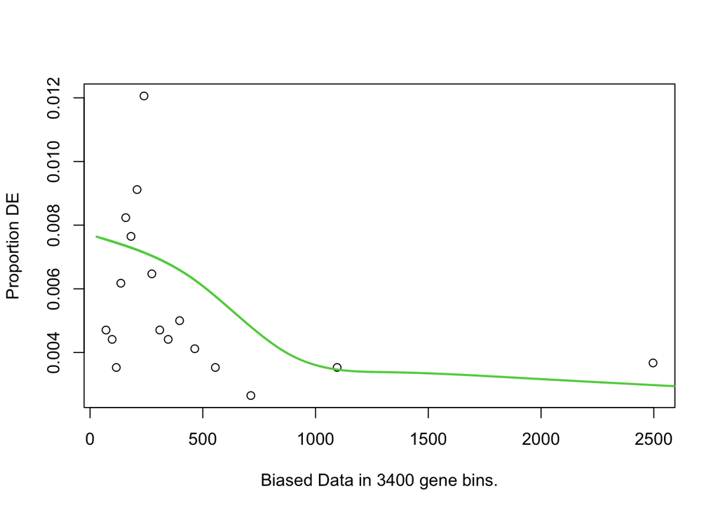

```r
pwf.C2<-nullp(clust2.genes, IDvector, bias.data=lengthVector) #weight vector by length of gene
```

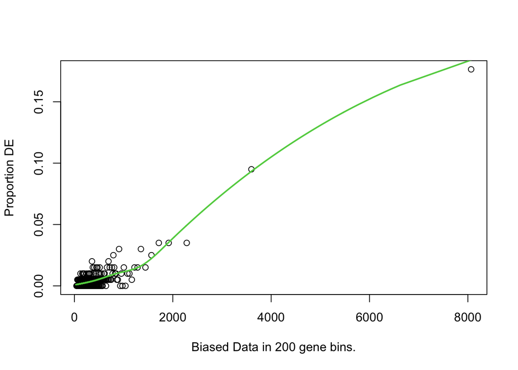

Prepare GO term dataframe

```r
GO.annot <- subset(annot, select=c(gene_id, GO_IDs))
GO.annot.na <- filter(GO.annot, GO_IDs!="NA;NA") #Remove NAs
GO.annot.na$GO_IDs <- gsub("NA;", "", GO.annot.na$GO_IDs)  #Remove NAs
GO.annot.na$GO_IDs <- gsub(";NA", "", GO.annot.na$GO_IDs)  #Remove NAs
splitted <- strsplit(as.character(GO.annot.na$GO_IDs), ";") #split into multiple GO ids
GO.terms <- data.frame(v1 = rep.int(GO.annot.na$gene_id, sapply(splitted, length)), v2 = unlist(splitted)) #list all genes with each of their GO terms in a single row
colnames(GO.terms) <- c("gene_id", "GO.ID")

GO.terms$GO.ID<- as.character(GO.terms$GO.ID)
GO.terms$GO.ID <- replace_na(GO.terms$GO.ID, "unknown")
GO.terms$GO.ID <- as.factor(GO.terms$GO.ID)
GO.terms$gene_id <- as.factor(GO.terms$gene_id)
GO.terms$GO.ID <- gsub(" ", "", GO.terms$GO.ID)
GO.terms <- unique(GO.terms)

dim(GO.terms)
```

```
## [1] 52067     2
```

```r
head(GO.terms, 10)
```

```
##               gene_id      GO.ID
## 1  adi2mcaRNA10013_R0 GO:0004674
## 2  adi2mcaRNA10013_R0 GO:0005524
## 3  adi2mcaRNA10013_R0 GO:0006468
## 4  adi2mcaRNA10013_R0 GO:0007165
## 5  adi2mcaRNA10013_R0 GO:0017049
## 6  adi2mcaRNA10016_R5 GO:0005576
## 7  adi2mcaRNA10016_R5 GO:0008061
## 8  adi2mcaRNA10017_R1 GO:0004526
## 9  adi2mcaRNA10017_R1 GO:0008033
## 12 adi2mcaRNA10018_R0 GO:0004930
```

```r
nrow(GO.terms)/length(unique(GO.terms$gene_id)) #avg GO IDs per gene
```

```
## [1] 2.25408
```

Find enriched GO terms, “selection-unbiased testing for category enrichment amongst significantly expressed genes for RNA-seq data”

```r
GOwall.C1 <- goseq(pwf.C1, GOref$gene_id, gene2cat=GO.terms, test.cats=c("GO:CC", "GO:BP", "GO:MF"), method="Wallenius", use_genes_without_cat=TRUE)
GOwall.C2 <- goseq(pwf.C2, GOref$gene_id, gene2cat=GO.terms, test.cats=c("GO:CC", "GO:BP", "GO:MF"), method="Wallenius", use_genes_without_cat=TRUE)
```

Find only enriched GO terms that are statistically significant at cutoff

```r
C1.GO.05<-GOwall.C1$category[GOwall.C1$over_represented_pvalue<.05]
C1.GO.05<-data.frame(C1.GO.05)
colnames(C1.GO.05) <- c("category")
C1.GO.05 <- merge(C1.GO.05, GOwall.C1, by="category")
C1.GO.05 <- C1.GO.05[order(C1.GO.05$ontology, C1.GO.05$over_represented_pvalue, -C1.GO.05$numDEInCat),]
C1.GO.05$term <- as.factor(C1.GO.05$term)
nrow(filter(C1.GO.05, ontology=="BP")) #number sig BP terms
```

```
## [1] 39
```

```r
nrow(filter(C1.GO.05, ontology=="MF")) #number sig MF terms
```

```
## [1] 31
```

```r
nrow(C1.GO.05)
```

```
## [1] 87
```

```r
C2.GO.05<-GOwall.C2$category[GOwall.C2$over_represented_pvalue<.05]
C2.GO.05<-data.frame(C2.GO.05)
colnames(C2.GO.05) <- c("category")
C2.GO.05 <- merge(C2.GO.05, GOwall.C2, by="category")
C2.GO.05 <- C2.GO.05[order(C2.GO.05$ontology, C2.GO.05$over_represented_pvalue, -C2.GO.05$numDEInCat),]
C2.GO.05$term <- as.factor(C2.GO.05$term)
nrow(filter(C2.GO.05, ontology=="BP")) #number sig BP terms
```

```
## [1] 5
```

```r
nrow(filter(C2.GO.05, ontology=="MF")) #number sig MF terms
```

```
## [1] 10
```

```r
nrow(C2.GO.05)
```

```
## [1] 18
```

Correct any un-annotated terms/ontologies

```r
NAs.ontology <- C1.GO.05 %>% subset(is.na(term))
print(NAs.ontology)
```

```
## [1] category                 over_represented_pvalue  under_represented_pvalue
## [4] numDEInCat               numInCat                 term
## [7] ontology
## <0 rows> (or 0-length row.names)
```

```r
NAs.ontology <- C2.GO.05 %>% subset(is.na(term))
print(NAs.ontology)
```

```
## [1] category                 over_represented_pvalue  under_represented_pvalue
## [4] numDEInCat               numInCat                 term
## [7] ontology
## <0 rows> (or 0-length row.names)
```

*There were no un-annotated functions except genes with unknown functions*

Save significant terms

```r
write.csv(C1.GO.05, file = "5-Planula-GO-Enrichment-Analysis/Output/GO.05.C1.csv", row.names = FALSE)
write.csv(C2.GO.05, file = "5-Planula-GO-Enrichment-Analysis/Output/GO.05.C2.csv", row.names = FALSE)
```

## Find GOslim terms

Read in files if previous steps not run.

```r
C1.GO.05 <- read_csv("5-Planula-GO-Enrichment-Analysis/Output/GO.05.C1.csv")
C1.GO.05$dir <- "C1 (Up)"
C2.GO.05 <- read_csv("5-Planula-GO-Enrichment-Analysis/Output/GO.05.C2.csv")
C2.GO.05$dir <- "C2 (Down)"
all_GO <- bind_rows(C1.GO.05, C2.GO.05)  #bind rows
str(all_GO)
```

```
## spec_tbl_df [105 × 8] (S3: spec_tbl_df/tbl_df/tbl/data.frame)
##  $ category                : chr [1:105] "GO:0006334" "GO:0007017" "GO:0006275" "GO:0072488" ...
##  $ over_represented_pvalue : num [1:105] 1.97e-19 2.22e-05 3.68e-04 1.72e-03 1.85e-03 ...
##  $ under_represented_pvalue: num [1:105] 1 1 1 1 1 ...
##  $ numDEInCat              : num [1:105] 13 4 2 2 2 2 2 2 2 1 ...
##  $ numInCat                : num [1:105] 41 30 5 12 13 14 14 17 18 1 ...
##  $ term                    : chr [1:105] "nucleosome assembly" "microtubule-based process" "regulation of DNA replication" "ammonium transmembrane transport" ...
##  $ ontology                : chr [1:105] "BP" "BP" "BP" "BP" ...
##  $ dir                     : chr [1:105] "C1 (Up)" "C1 (Up)" "C1 (Up)" "C1 (Up)" ...
##  - attr(*, "spec")=
##   .. cols(
##   ..   category = col_character(),
##   ..   over_represented_pvalue = col_double(),
##   ..   under_represented_pvalue = col_double(),
##   ..   numDEInCat = col_double(),
##   ..   numInCat = col_double(),
##   ..   term = col_character(),
##   ..   ontology = col_character()
##   .. )
##  - attr(*, "problems")=<externalptr>
```

Run GOslim to get broader categories

```r
slim <- getOBOCollection("http://current.geneontology.org/ontology/subsets/goslim_generic.obo") #get GO database

## BP
BP_GO <- all_GO %>%
  filter(ontology=="BP")
BPGO_collection <- GOCollection(BP_GO$category) #Make library of query terms
slims_bp <- data.frame(goSlim(BPGO_collection, slim, "BP")) #Find common parent terms to slim down our list
slims_bp$category <- row.names(slims_bp) #save rownames as category

## MF
MF_GO <- all_GO %>%
  filter(ontology=="MF")
MFGO_collection <- GOCollection(MF_GO$category) #Make library of query terms
slims_mf <- data.frame(goSlim(MFGO_collection, slim, "MF")) #Find common parent terms to slim down our list
slims_mf$category <- row.names(slims_mf) #save rownames as category
```

Get mapped terms, using functions from Sam White’s Biostars [post](https://support.bioconductor.org/p/128407/#128409).

```r
#Write function mappedIds to get the query terms that mapped to the slim categories
mappedIds <-
  function(df, collection, OFFSPRING) #the command to run requires a dataframe of slim terms, like slims_MF above, your list of query terms, and the offspring from the GOCollection by goSlim
  {
    map <- as.list(OFFSPRING[rownames(df)]) # Subset GOcollection offspring by the rownames of your dataframe
    mapped <- lapply(map, intersect, ids(collection)) #Find the terms that intersect between the subset made above of your query terms and the GOids from the GO collection
    df[["go_terms"]] <- vapply(unname(mapped), paste, collapse = ";", character(1L)) #Add column "go_terms" with matching terms
    df #show resulting dataframe
  }
#Run function for MF and BP terms
BPslim <- mappedIds(slims_bp, BPGO_collection, GOBPOFFSPRING)
MFslim <- mappedIds(slims_mf, MFGO_collection, GOMFOFFSPRING)
```

Remove duplicate matches, keeping the broader umbrella term

```r
#BP
BPslim <- filter(BPslim, Count>0 & Term!="biological_process") #filter out empty slims and term "biological process"
BPsplitted <- strsplit(as.character(BPslim$go_terms), ";") #split into multiple GO ids
BPslimX <- data.frame(Term = rep.int(BPslim$Term, sapply(BPsplitted, length)), go_term = unlist(BPsplitted)) #list all
BPslimX <- merge(BPslimX, BPslim[,c(1,3:4)], by="Term") #Add back counts, term, and category info
BPslimX <- unique(setDT(BPslimX)[order(go_term, -Count)], by = "go_term") #remove duplicate offspring terms, keeping only those that appear in the larger umbrella term (larger Count number)
BPslim <- data.frame(slim_term=BPslimX$Term, slim_cat=BPslimX$category, category=BPslimX$go_term) #rename columns
head(BPslim)
```

```
##                                slim_term   slim_cat   category
## 1            cellular component assembly GO:0022607 GO:0000027
## 2                             cell cycle GO:0007049 GO:0000070
## 3                   biosynthetic process GO:0009058 GO:0000122
## 4                             cell cycle GO:0007049 GO:0000281
## 5                    signal transduction GO:0007165 GO:0002224
## 6 generation of precursor metabolites... GO:0006091 GO:0006122
```

```r
#MF
MFslim <- filter(MFslim, Count>0 & Term!="molecular_function") #filter out empty slims and term "molecular function"
MFsplitted <- strsplit(as.character(MFslim$go_terms), ";") #split into multiple GO ids
MFslimX <- data.frame(Term = rep.int(MFslim$Term, sapply(MFsplitted, length)), go_term = unlist(MFsplitted)) #list all
MFslimX <- merge(MFslimX, MFslim[,c(1,3:4)], by="Term")  #Add back counts, term, and category info
MFslimX <- unique(setDT(MFslimX)[order(go_term, -Count)], by = "go_term")  #remove duplicate offspring terms, keeping only
MFslim <- data.frame(slim_term=MFslimX$Term, slim_cat=MFslimX$category, category=MFslimX$go_term) #rename columns
head(MFslim)
```

```
##                                slim_term   slim_cat   category
## 1                            DNA binding GO:0003677 GO:0003697
## 2 hydrolase activity, acting on carbo... GO:0016810 GO:0003726
## 3           cytoskeletal protein binding GO:0008092 GO:0003779
## 4        nucleotidyltransferase activity GO:0016779 GO:0003968
## 5                     peptidase activity GO:0008233 GO:0004222
## 6                         lyase activity GO:0016829 GO:0004451
```

Save slim info with GO enrichment info for heatmap dataframes.

```r
GO.BP <- right_join(BPslim, filter(all_GO, ontology=="BP"), by="category") #add back GO enrichment info for each offspring term
GO.MF <- right_join(MFslim, filter(all_GO, ontology=="MF"), by="category") #add back GO enrichment info for each offspring term
```

## Make heatmap

```r
BPplot <- GO.BP %>% filter(numInCat>5) %>% mutate(term = fct_reorder(term, -over_represented_pvalue)) %>% ggplot(aes(x = dir, y = term)) +
  geom_tile(aes(fill=over_represented_pvalue, width = 1)) +
  facet_grid(slim_term ~ ontology, scales = "free_y", labeller = label_wrap_gen(width = 10, multi_line = TRUE))+
  theme_bw() + theme(panel.border = element_blank(), panel.grid.major = element_blank(),
  panel.grid.minor = element_blank(), axis.line = element_line(colour = "black"),
  strip.text.y = element_text(angle=0, size = 11, face = "bold"),
  strip.text.x = element_text(size = 12, face = "bold"),
  axis.title.x = element_blank(),
  axis.title.y = element_text(size=15),
  axis.text = element_text(size = 12), legend.position = "None",
  plot.margin = unit(c(0,1,0,0.25), "cm"))

MFplot <- GO.MF %>% filter(numInCat>5) %>% mutate(term = fct_reorder(term, -over_represented_pvalue)) %>% ggplot(aes(x = dir, y = term)) +
  geom_tile(aes(fill=over_represented_pvalue, width = 1)) +
  scale_y_discrete(position = "right") +
  facet_grid(slim_term ~ ontology, scales = "free_y", labeller = label_wrap_gen(width = 10, multi_line = TRUE),
             switch="y") + #Put the y facet strips on the left
  theme_bw() + theme(panel.border = element_blank(), panel.grid.major = element_blank(),
  panel.grid.minor = element_blank(), axis.line = element_line(colour = "black"),
  strip.text.y.left = element_text(angle=0, size = 11, face = "bold"),
  strip.text.x = element_text(size = 12, face = "bold"),
  axis.title = element_blank(),
  axis.text = element_text(size = 12), legend.title = element_text(size = 12), legend.text = element_text(size = 11))

fig5 <- BPplot + MFplot
fig5 <- ggdraw(plot = fig5) + draw_plot_label(c("a)", "b)"), c(0, 0.33), c(1, 1), size = 15)
ggsave("5-Planula-GO-Enrichment-Analysis/Output/fig5_GOslim.pdf", fig5, width = 20, height = 2, units = c("in"))
ggsave("Final_figures/Fig5.png", fig5, width = 20, height = 20, units = c("in"))
```

## Make supplemental table summarizing GO enrichment

Must do separately for C1 (u)p and C2 (down) so we don’t get duplicate gene entries.

```r
DF_GOhm <- bind_rows(GO.BP, GO.MF)
head(DF_GOhm)
```

```
##                                slim_term   slim_cat   category
## 1            cellular component assembly GO:0022607 GO:0000027
## 2                             cell cycle GO:0007049 GO:0000070
## 3                   biosynthetic process GO:0009058 GO:0000122
## 4                             cell cycle GO:0007049 GO:0000281
## 5                    signal transduction GO:0007165 GO:0002224
## 6 generation of precursor metabolites... GO:0006091 GO:0006122
##   over_represented_pvalue under_represented_pvalue numDEInCat numInCat
## 1             0.012331059                0.9999619          1        2
## 2             0.011755679                0.9999654          1        2
## 3             0.023747629                0.9997871          1        4
## 4             0.008262179                0.9999829          1        2
## 5             0.030797153                0.9996171          1        5
## 6             0.025237835                0.9997594          1        4
##                                                          term ontology     dir
## 1                            ribosomal large subunit assembly       BP C1 (Up)
## 2                        mitotic sister chromatid segregation       BP C1 (Up)
## 3   negative regulation of transcription by RNA polymerase II       BP C1 (Up)
## 4                                         mitotic cytokinesis       BP C1 (Up)
## 5                        toll-like receptor signaling pathway       BP C1 (Up)
## 6 mitochondrial electron transport, ubiquinol to cytochrome c       BP C1 (Up)
```

```r
#Separate up and down
DF_GOhm_U <- filter(DF_GOhm, dir=="C1 (Up)")
DF_GOhm_D <- filter(DF_GOhm, dir=="C2 (Down)")
```

Make dataframe of GO results for clustering and heatmap.

```r
#add gene_IDs. To get gene_IDs we will merge with the GO.terms DF.
GOgenes <- data.frame(gene_id=GO.terms$gene_id, category=GO.terms$GO.ID) #First have to make the "by" column the same for both
#GOgenes$gene_id <- as.character(GOgenes$gene_id)
```

Using R script from Mass Lab. Needs columns “experiment” where we will put cluster information, “term”, “percentDEInCat”, and “gene” with all the DE genes associated with that GO term.

```r
#DO UP (C1)
GOgenes_U <- filter(GOgenes, gene_id%in%clust1$gene_id)
GOdf_U <- left_join(DF_GOhm_U, GOgenes_U, by="category" ) #join the DFs
GOdf_U$gene_id <- as.character(GOdf_U$gene_id) #make gene ID a character so we can collapse our many near-identical columns
GOdf_U <- GOdf_U %>% #collapse and have gene IDs for a particular term in a single row as a comma-sep list.
  filter(gene_id%in%DEGclust$gene_id) %>%
  group_by(ontology, slim_term, slim_cat, category, term, over_represented_pvalue, numDEInCat, numInCat, dir) %>%
  summarise(genes = toString(gene_id)) %>% #rename collapsed gene_ID column "gene"
  ungroup()
#DO DOWN (C2)
GOgenes_D <- filter(GOgenes, gene_id%in%clust2$gene_id)
GOdf_D <- left_join(DF_GOhm_D, GOgenes_D, by="category" ) #join the DFs
GOdf_D$gene_id <- as.character(GOdf_D$gene_id) #make gene ID a character so we can collapse our many near-identical columns
GOdf_D <- GOdf_D %>% #collapse and have gene IDs for a particular term in a single row as a comma-sep list.
  filter(gene_id%in%DEGclust$gene_id) %>%
  group_by(ontology, slim_term, slim_cat, category, term, over_represented_pvalue, numDEInCat, numInCat, dir) %>%
  summarise(genes = toString(gene_id)) %>% #rename collapsed gene_ID column "gene"
  ungroup()
```

Bind rows for up and down and save!

```r
GOdf <- bind_rows(GOdf_U, GOdf_D)
head(GOdf)
```

```
## # A tibble: 6 × 10
##   ontology slim_term   slim_cat  category term       over_represente… numDEInCat
##   <chr>    <chr>       <chr>     <chr>    <chr>                 <dbl>      <dbl>
## 1 BP       biosynthet… GO:00090… GO:0000… negative …         0.0237            1
## 2 BP       biosynthet… GO:00090… GO:0006… GTP biosy…         0.0357            1
## 3 BP       biosynthet… GO:00090… GO:0006… UTP biosy…         0.0357            1
## 4 BP       biosynthet… GO:00090… GO:0006… dTMP bios…         0.0117            1
## 5 BP       biosynthet… GO:00090… GO:0006… CTP biosy…         0.0402            1
## 6 BP       biosynthet… GO:00090… GO:0006… regulatio…         0.000368          2
## # … with 3 more variables: numInCat <dbl>, dir <chr>, genes <chr>
```

```r
str(GOdf)
```

```
## tibble [85 × 10] (S3: tbl_df/tbl/data.frame)
##  $ ontology               : chr [1:85] "BP" "BP" "BP" "BP" ...
##  $ slim_term              : chr [1:85] "biosynthetic process" "biosynthetic process" "biosynthetic process" "biosynthetic process" ...
##  $ slim_cat               : chr [1:85] "GO:0009058" "GO:0009058" "GO:0009058" "GO:0009058" ...
##  $ category               : chr [1:85] "GO:0000122" "GO:0006183" "GO:0006228" "GO:0006231" ...
##  $ term                   : chr [1:85] "negative regulation of transcription by RNA polymerase II" "GTP biosynthetic process" "UTP biosynthetic process" "dTMP biosynthetic process" ...
##  $ over_represented_pvalue: num [1:85] 0.0237 0.0357 0.0357 0.0117 0.0402 ...
##  $ numDEInCat             : num [1:85] 1 1 1 1 1 2 2 1 1 1 ...
##  $ numInCat               : num [1:85] 4 6 6 2 7 5 14 1 1 1 ...
##  $ dir                    : chr [1:85] "C1 (Up)" "C1 (Up)" "C1 (Up)" "C1 (Up)" ...
##  $ genes                  : chr [1:85] "g58547" "g51181" "g51181" "g30099" ...
```

```r
write.csv(GOdf, file = "5-Planula-GO-Enrichment-Analysis/Output/GOenrichmentsummary.csv", row.names = FALSE)
```

## Kegg enrichment analysis

Load KO – gene mapping info

```r
#Extract from InterProScan search Chille et al., 2021 project
IPS.KO <- na.omit(subset(annot, select=c(gene_id, ko)))
IPS.KO$ko <- gsub("\\;", "", IPS.KO$ko)

#Load in and prep KofamScan search results
KFS.KO.orig <- read_tsv("5-Planula-GO-Enrichment-Analysis/a-Kegg-ontology/Mcap_KO_annot.tsv", col_names = TRUE)
KFS.KO <- KFS.KO.orig[-1,c(1,2,3)]
colnames(KFS.KO) <- c("sig","gene_id", "ko")
KFS.KO <- filter(KFS.KO, sig=="*")
KFS.KO <- KFS.KO[,c(2:3)]
KFS.KO$gene_id <- gsub("augustus.", "", KFS.KO$gene_id)
KFS.KO$gene_id <- gsub(".t1", "", KFS.KO$gene_id)
head(KFS.KO)
```

```
## # A tibble: 6 × 2
##   gene_id            ko
##   <chr>              <chr>
## 1 adi2mcaRNA10017_R1 K03539
## 2 adi2mcaRNA10073_R0 K16506
## 3 adi2mcaRNA10131_R0 K23679
## 4 adi2mcaRNA10132_R0 K04567
## 5 adi2mcaRNA1019_R0  K05810
## 6 adi2mcaRNA1021_R0  K00626
```

```r
tail(KFS.KO)
```

```
## # A tibble: 6 × 2
##   gene_id ko
##   <chr>   <chr>
## 1 g9976   K08738
## 2 g9977   K24730
## 3 g9978   K02989
## 4 g9979   K07192
## 5 g9989   K09291
## 6 g9990   K09291
```

```r
#bind all KO results
#KO.terms <- bind_rows(IPS.KO, KFS.KO)
KO.terms <- KFS.KO
KO.terms <- unique(KO.terms)
str(KO.terms)
```

```
## tibble [10,353 × 2] (S3: tbl_df/tbl/data.frame)
##  $ gene_id: chr [1:10353] "adi2mcaRNA10017_R1" "adi2mcaRNA10073_R0" "adi2mcaRNA10131_R0" "adi2mcaRNA10132_R0" ...
##  $ ko     : chr [1:10353] "K03539" "K16506" "K23679" "K04567" ...
```

```r
head(KO.terms)
```

```
## # A tibble: 6 × 2
##   gene_id            ko
##   <chr>              <chr>
## 1 adi2mcaRNA10017_R1 K03539
## 2 adi2mcaRNA10073_R0 K16506
## 3 adi2mcaRNA10131_R0 K23679
## 4 adi2mcaRNA10132_R0 K04567
## 5 adi2mcaRNA1019_R0  K05810
## 6 adi2mcaRNA1021_R0  K00626
```

```r
colnames(KO.terms) <- c("gene_id", "GO.ID")
#Bind KO and GO references
GOKO.terms <- bind_rows(GO.terms, KO.terms)
```

Perform Kegg enrichment with goseq package

```r
#Perform goseq
KOwall.C1 <- goseq(pwf.C1, GOref$gene_id, gene2cat=GOKO.terms, test.cats=c("KEGG"), method="Wallenius", use_genes_without_cat=TRUE)
```

```
## Using manually entered categories.
```

```
## Calculating the p-values...
```

```r
KOwall.C2 <- goseq(pwf.C2, GOref$gene_id, gene2cat=GOKO.terms, test.cats=c("KEGG"), method="Wallenius", use_genes_without_cat=TRUE)
```

```
## Using manually entered categories.
```

```
## Calculating the p-values...
```

Replace NAs with “KEGG” and extract KO terms from results

```r
#Cluster1
C1.KO.05<-KOwall.C1$category[KOwall.C1$over_represented_pvalue<.05]
C1.KO.05<-data.frame(C1.KO.05)
colnames(C1.KO.05) <- c("category")
C1.KO.05 <- merge(C1.KO.05, KOwall.C1, by="category")
C1.KO.05$ontology <- replace_na(C1.KO.05$ontology, "KEGG")
C1.KO.05 <- filter(C1.KO.05, ontology=="KEGG")
C1.KO.05 <- C1.KO.05[order(C1.KO.05$ontology, C1.KO.05$over_represented_pvalue, -C1.KO.05$numDEInCat),]
C1.KO.05$term <- as.factor(C1.KO.05$term)
nrow(C1.KO.05)
```

```
## [1] 78
```

```r
#Cluster2
C2.KO.05<-KOwall.C2$category[KOwall.C2$over_represented_pvalue<.05]
C2.KO.05<-data.frame(C2.KO.05)
colnames(C2.KO.05) <- c("category")
C2.KO.05 <- merge(C2.KO.05, KOwall.C2, by="category")
C2.KO.05$ontology <- replace_na(C2.KO.05$ontology, "KEGG")
C2.KO.05 <- filter(C2.KO.05, ontology=="KEGG")
C2.KO.05 <- C2.KO.05[order(C2.KO.05$ontology, C2.KO.05$over_represented_pvalue, -C2.KO.05$numDEInCat),]
C2.KO.05$term <- as.factor(C2.KO.05$term)
nrow(C2.KO.05)
```

```
## [1] 15
```

Add KO definitions

```r
#Prep definition data
KFS.KO.def <- subset(KFS.KO.orig, select=c("#","KO", "KO definition"))
colnames(KFS.KO.def) <- c("sig","category", "term")
KFS.KO.def <- filter(KFS.KO.def, sig=="*")
KFS.KO.def <- KFS.KO.def[,c(2:3)]

#Merge with KEGG output
C1.KO.05 <- unique(left_join(C1.KO.05[,-6], KFS.KO.def, by=c("category")))
C2.KO.05 <- unique(left_join(C2.KO.05[,-6], KFS.KO.def, by=c("category")))
```

Write output KEGG enrichment files

```r
write.csv(C1.KO.05, file = "5-Planula-GO-Enrichment-Analysis/Output/KO.05.C1.csv")
write.csv(C2.KO.05, file = "5-Planula-GO-Enrichment-Analysis/Output/KO.05.C2.csv")
```

## Make supplemental table summarizing KO enrichment

Must do separately for C1 (u)p and C2 (down) so we don’t get duplicate gene entries. Add dir info

```r
#Add dir info
C1.KO.05$dir <- "C1 (Up)"
C2.KO.05$dir <- "C2 (Down)"
```

Make dataframe of GO results for clustering and heatmap.

```r
#add gene_IDs. To get gene_IDs we will merge with the GO.terms DF.
GOKOgenes <- data.frame(gene_id=GOKO.terms$gene_id, category=GOKO.terms$GO.ID) #First have to make the "by" column the same for both
#GOgenes$gene_id <- as.character(GOgenes$gene_id)
```

Using R script from Mass Lab. Needs columns “experiment” where we will put cluster information, “term”, “percentDEInCat”, and “gene” with all the DE genes associated with that GO term.

```r
#DO UP (C1)
KOgenes_U <- filter(GOKOgenes, gene_id%in%clust1$gene_id)
KOdf_U <- left_join(C1.KO.05, KOgenes_U, by="category" ) #join the DFs
KOdf_U$gene_id <- as.character(KOdf_U$gene_id) #make gene ID a character so we can collapse our many near-identical columns
KOdf_U <- KOdf_U %>% #collapse and have gene IDs for a particular term in a single row as a comma-sep list.
  filter(gene_id%in%DEGclust$gene_id) %>%
  group_by(ontology, category, term, over_represented_pvalue, numDEInCat, numInCat, dir) %>%
  summarise(genes = toString(gene_id)) %>% #rename collapsed gene_ID column "gene"
  ungroup()
#DO DOWN (C2)
KOgenes_D <- filter(GOKOgenes, gene_id%in%clust2$gene_id)
KOdf_D <- left_join(C2.KO.05, KOgenes_D, by="category" ) #join the DFs
KOdf_D$gene_id <- as.character(KOdf_D$gene_id) #make gene ID a character so we can collapse our many near-identical columns
KOdf_D <- KOdf_D %>% #collapse and have gene IDs for a particular term in a single row as a comma-sep list.
  filter(gene_id%in%DEGclust$gene_id) %>%
  group_by(ontology, category, term, over_represented_pvalue, numDEInCat, numInCat, dir) %>%
  summarise(genes = toString(gene_id)) %>% #rename collapsed gene_ID column "gene"
  ungroup()
```

Bind rows for up and down and save!

```r
KOdf <- bind_rows(KOdf_U, KOdf_D)
head(KOdf)
```

```
## # A tibble: 6 × 8
##   ontology category term        over_represente… numDEInCat numInCat dir   genes
##   <chr>    <chr>    <chr>                  <dbl>      <int>    <int> <chr> <chr>
## 1 KEGG     K00419   ubiquinol-…          0.0128           1        2 C1 (… g491…
## 2 KEGG     K00526   ribonucleo…          0.00564          1        1 C1 (… g539…
## 3 KEGG     K00560   thymidylat…          0.0117           1        2 C1 (… g300…
## 4 KEGG     K00784   ribonuclea…          0.0193           1        4 C1 (… g3410
## 5 KEGG     K00940   nucleoside…          0.0296           1        5 C1 (… g511…
## 6 KEGG     K01637   isocitrate…          0.0109           1        2 C1 (… g404…
```

```r
str(KOdf)
```

```
## tibble [93 × 8] (S3: tbl_df/tbl/data.frame)
##  $ ontology               : chr [1:93] "KEGG" "KEGG" "KEGG" "KEGG" ...
##  $ category               : chr [1:93] "K00419" "K00526" "K00560" "K00784" ...
##  $ term                   : chr [1:93] "ubiquinol-cytochrome c reductase subunit 9" "ribonucleoside-diphosphate reductase beta chain [EC:1.17.4.1]" "thymidylate synthase [EC:2.1.1.45]" "ribonuclease Z [EC:3.1.26.11]" ...
##  $ over_represented_pvalue: num [1:93] 0.0128 0.00564 0.01174 0.01932 0.02957 ...
##  $ numDEInCat             : int [1:93] 1 1 1 1 1 1 1 1 2 1 ...
##  $ numInCat               : int [1:93] 2 1 2 4 5 2 3 4 14 5 ...
##  $ dir                    : chr [1:93] "C1 (Up)" "C1 (Up)" "C1 (Up)" "C1 (Up)" ...
##  $ genes                  : chr [1:93] "g49169" "g53997" "g30099" "g3410" ...
```

```r
write.csv(KOdf, file = "5-Planula-GO-Enrichment-Analysis/Output/KOenrichmentsummary.csv", row.names = FALSE)
```

Testing overlap of KO goseq results with original Mcap annotation

```r
#KOdfwithIPS <- KOdf

#nrow(IPS.KO)
#nrow(KOdf)
# nrow(KOdfwithIPS)
# intersect(KOdf$category, IPS.KO$ko)
# intersect(IPS.KO$ko, KOdf$category)

# KOdf
# KOdfwithIPS
# all(KOdf$category==KOdfwithIPS$category)
# all(KOdf$over_represented_pvalue==KOdfwithIPS$over_represented_pvalue)
# all(KOdf$numDEInCat==KOdfwithIPS$numDEInCat)
# all(KOdf$numInCat==KOdfwithIPS$numInCat)
# all(KOdf$dir==KOdfwithIPS$dir)
# all(KOdf$genes==KOdfwithIPS$genes)

# setdiff(KOdf$category,KOdfwithIPS$category)
# setdiff(KOdf$over_represented_pvalue,KOdfwithIPS$over_represented_pvalue)
# setdiff(KOdf$numDEInCat,KOdfwithIPS$numDEInCat)
# setdiff(KOdf$numInCat,KOdfwithIPS$numInCat)
# setdiff(KOdf$dir,KOdfwithIPS$dir)
# setdiff(KOdf$genes,KOdfwithIPS$genes)

# setdiff(KOdfwithIPS$category,KOdf$category)
# setdiff(KOdfwithIPS$over_represented_pvalue,KOdf$over_represented_pvalue)
# setdiff(KOdfwithIPS$numDEInCat,KOdf$numDEInCat)
# setdiff(KOdfwithIPS$numInCat,KOdf$numInCat)
# setdiff(KOdfwithIPS$dir,KOdf$dir)
# setdiff(KOdfwithIPS$genes,KOdf$genes)

# KOdfwithIPS.noK07937 <- filter(KOdfwithIPS, category!="K07937")
# all(KOdf$category==KOdfwithIPS.noK07937$category)
# all(KOdf$over_represented_pvalue==KOdfwithIPS.noK07937$over_represented_pvalue)
# all(KOdf$numDEInCat==KOdfwithIPS.noK07937$numDEInCat)
# all(KOdf$numInCat==KOdfwithIPS.noK07937$numInCat)
# all(KOdf$dir==KOdfwithIPS.noK07937$dir)
# all(KOdf$genes==KOdfwithIPS.noK07937$genes)
```